# Module12

Itzel Zapata-Oropesa

4/11/2022

## Assignment

Create your own Markdown file and post the code on GitHub and your reflection on the process of Markdown in your blog.  
This is just a reminder that an R Markdown is just a document. By studying the document source code file, compiling it, and observing the result, side-by-side with the source, you’ll learn a lot about the R Markdown and LaTeX mathematical typesetting language, and you’ll be able to produce nice-looking documents with R input and output neatly formatted. The content of your R Markdown can be the main functions you are creating for your final project where you will describe those functions or create FAQ to your final project. It is your decision. The key formatting constructs are discussed at http://rmarkdown.rstudio.com/authoring_basics.html Dr. Friedman

## Libraries

Here we will load the libraries required for our code.

```r
library(ggplot2)
```

## Our code

To demonstrate the full use of our R Markdown file, we will explore the airquality dataset

```r
air <- airquality
head(air)
```

```
##   Ozone Solar.R Wind Temp Month Day
## 1    41     190  7.4   67     5   1
## 2    36     118  8.0   72     5   2
## 3    12     149 12.6   74     5   3
## 4    18     313 11.5   62     5   4
## 5    NA      NA 14.3   56     5   5
## 6    28      NA 14.9   66     5   6
```

```r
#fill in missing values
air$Ozone[is.na(air$Ozone)]<-mean(air$Ozone,na.rm=TRUE)
air$Solar.R[is.na(air$Solar.R)] <- mean(air$Solar.R, na.rm = TRUE)
```

## Plotting the Data

This is where we create a plot for our data

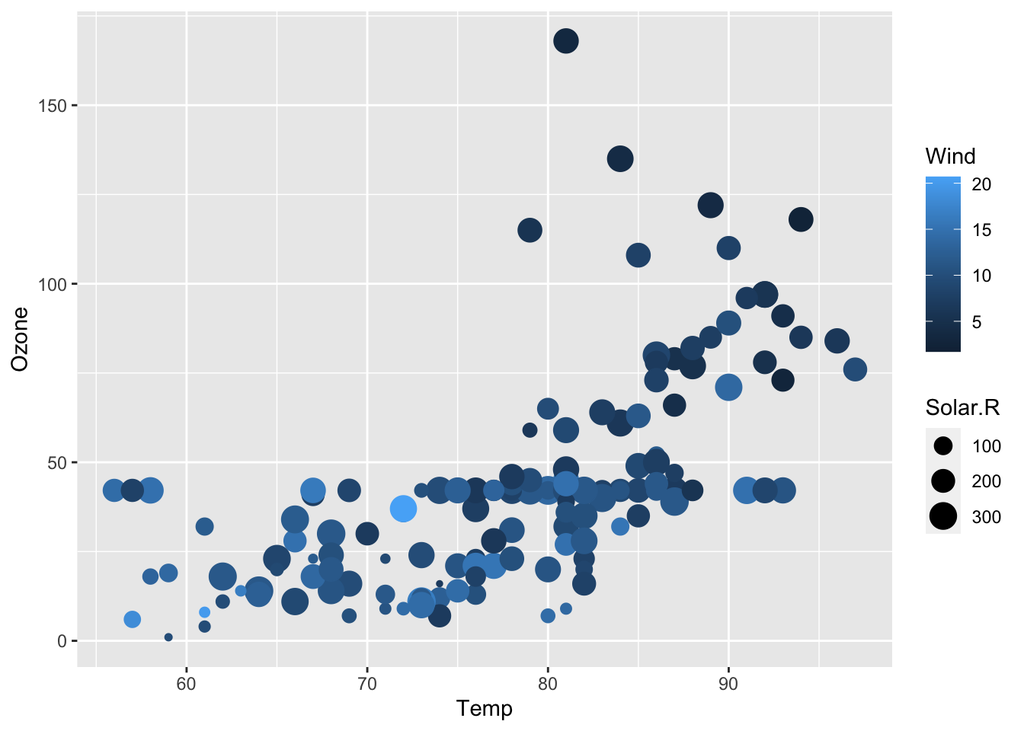

```r
ggplot(air, aes(x = Temp, y = Ozone, color = Wind, size = Solar.R)) +
  geom_point()
```